# Regression Models Course Project

Huascar Duarte

September 20th, 2014

## Executive Summary

Famous automobile magazine Motor Trend has comissioned us to explore the relationship between a set of variables and fuel consumption mesured in miles per gallon. They are particularly interested in the following two questions:

- “Is an automatic or manual transmission better for MPG?”
- “What is the MPG difference between automatic and manual transmissions?”

## Question

Take the mtcars data set and write up an analysis to answer their question using regression models and exploratory data analyses.

Your report must be:

- Written as a PDF printout of a compiled (using knitr) R markdown document.
- Brief. Roughly the equivalent of 2 pages or less for the main text. Supporting figures in an appendix can be included up to 5 total pages including the 2 for the main report. The appendix can only include figures.
- Include a first paragraph executive summary.

## Evaluation

Following points will be evaluated:

- Did the student interpret the coefficients correctly?
- Did the student do some exploratory data analyses?
- Did the student fit multiple models and detail their strategy for model selection?
- Did the student answer the questions of interest or detail why the question(s) is (are) not answerable?
- Did the student do a residual plot and some diagnostics?
- Did the student quantify the uncertainty in their conclusions and/or perform an inference correctly?
- Was the report brief (about 2 pages long) for the main body of the report and no longer than 5 with supporting appendix of figures?
- Did the report include an executive summary?
- Was the report done in Rmd (knitr)?

## Data

The `mtcars` dataset provided in R’s `datasets` library will be used to explore the relaitonship berween fuel consumption and other variables.

The data in this dataset was extracted from the 1974 *Motor Trend* US magazine, and comprises fuel consumption and 10 aspects of automobile design and performance for 32 automobiles (1973–74 models), providing the information below, some o which we will not use in our analysis, since they are not directly related to fuel consumption:

1. **mpg** - Miles/(US) gallon
2. cyl - Number of cylinders *(not used)*
3. **disp** - Displacement (cu.in.), i.e., total cubic capacity of cylinders
4. **hp** - Gross horsepower
5. drat - Rear axle ratio *(not used)*
6. **wt** - Weight (lb/1000)
7. qsec - 1/4 mile time *(not used)*
8. vs - Disposition of cylinders (V or Straight) *(not used)*
9. **am** - Transmission (0 = automatic, 1 = manual)
10. gear - Number of forward gears *(not used)*
11. carb - Number of carburetors *(not used)*

The following code will subset the data we are interested in the data frame `cars`:

```r
cars <- mtcars[,c(1, 3, 4, 6, 9)] #Select the columns we want
cars$am<-as.factor(cars$am) #Make the am column into factor
```

## Models

### Simple mean

As shown in figure 2, adopting a simple model considering only the transmission type, we can say, with 95% confidence, that cars with automatic transmissions have a fuel consumption between **14.9** and **19.4 mpg**, with a mean of **17.1 mpg**, while manual transmission cars have a fuel consumption between **21.6** and **27.2 mpg**, with a mean of **24.4 mpg**, i.e.:

> Automatic transmission cars burn between **39.7%** and **45.6%** more fuel than manual transmission cars!

## Appendix

**Fig. 1: Pairs with red dots for manual and green dots for automatic**

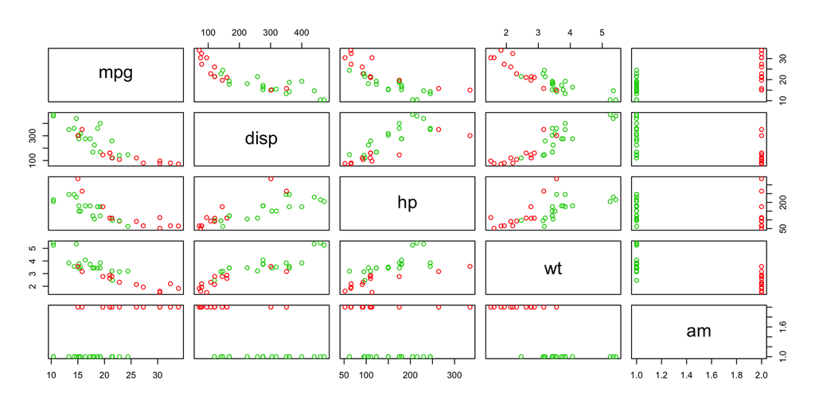

```r
pairs(cars, col = 2 + (cars$am == 0))
```

**Fig. 2: Boxplot with 95% confidence intervals**

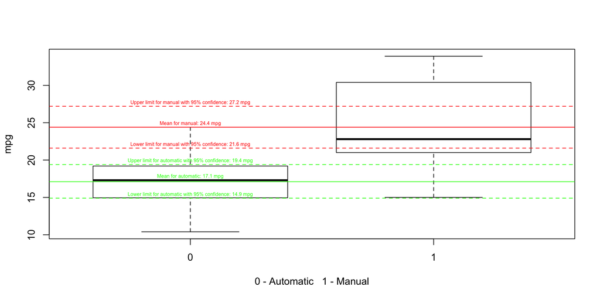